# Prophet Library in R

Neha Deshmukh

6th December 2018

# Prophet

## Why is Prophet useful?

- **Prophet** is a time series forecasting package available in R which is heavily used by companies to tell them where they will be weeks/months/years from now.
- Accurate and fast.
- Gets reasonable forecast with no manual effort.
- Tunable Forecasts.
- Works best with more historical data.

## Prophet function arguments

prophet(df = NULL, growth = “linear”, changepoints = NULL, yearly.seasonality = “auto”, weekly.seasonality = “auto”, daily.seasonality = “auto”, holidays = NULL, …)

- **df**: Dataframe containing the history. Consists of dates and time series values.
- **Growth**: linear or logistic trend.
- **Changepoints**: Vector of dates at which to include potential changepoints.
- **yearly.seasonality**: Fit yearly seasonality.
- **Weekly.seasonality**: Fit weely seasonality.
- **daily.seasonality**: Fit daily seasonality.
- **Holidays**: For modeling holidays and recurring events. Requires another dataframe of holiday dates.

## About the dataset

```r
lj1 <- read.csv("E:/neha/studies/trent study material/Data Analysis with R/lj.csv", header=TRUE)
head(lj1)
```

```
##         Date LeBron.James
## 1 2015-07-01       404617
## 2 2015-08-01       296762
## 3 2015-09-01       332765
## 4 2015-10-01       341296
## 5 2015-11-01       420578
## 6 2015-12-01       534973
```

## Importing the data

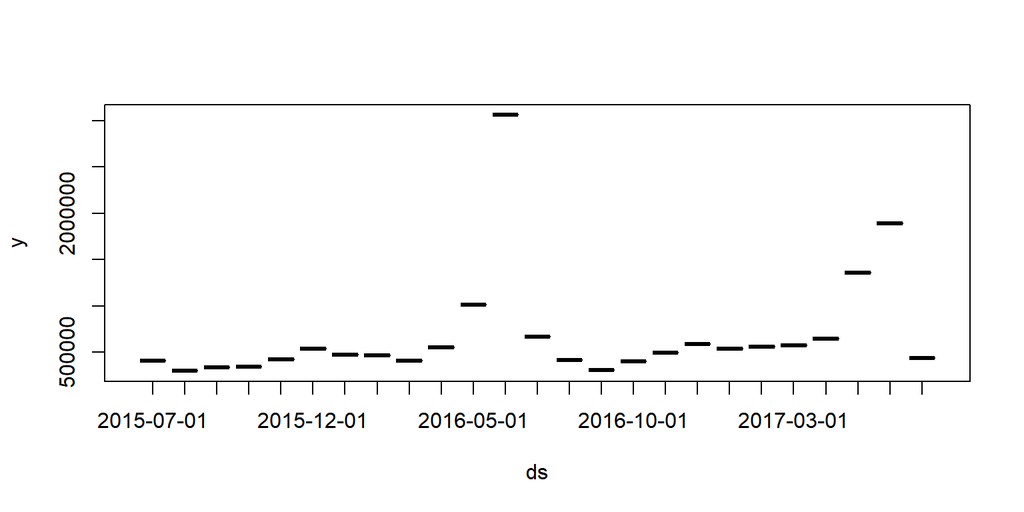

```r
#loading the dataset
lj1 <- read.csv("E:/neha/studies/trent study material/Data Analysis with R/lj.csv", header=TRUE)
colnames(lj1) <- c("ds", "y")
plot(y ~ ds, lj1, type="l")
```

## make_future_dataframe and predict

- **make_future_dataframe** is a built in function in prophet to make a dataframe of future dates.
- **predict()** is used to make prediction for each row in the future dataframe created using the **make_future_dataframe**.

## Using the Prophet Function

Prophet function is used to fit the model.

```r
m <- prophet(lj1)
future <- make_future_dataframe(m, periods = 365)
forecast <- predict(m, future)
tail(forecast[c("ds", "yhat", "yhat_lower", "yhat_upper")])
```

```
##             ds     yhat yhat_lower yhat_upper
## 385 2018-06-26 386228.4   163981.5   618983.8
## 386 2018-06-27 377162.7   131295.6   601077.4
## 387 2018-06-28 382480.5   157662.4   622740.1
## 388 2018-06-29 400983.3   183605.6   630823.2
## 389 2018-06-30 431185.4   213143.6   650831.1
## 390 2018-07-01 471360.3   231506.2   695743.8
```

## Plot the predictions

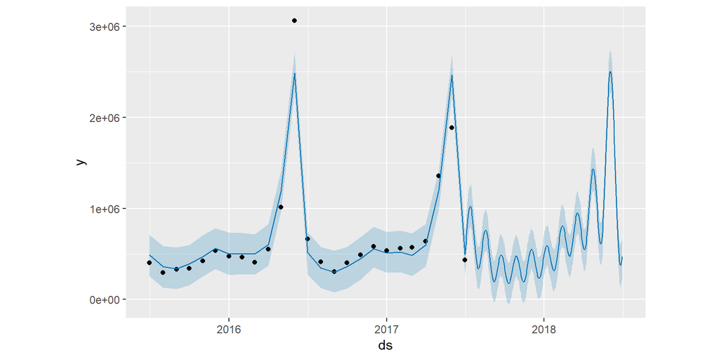

```r
plot(m,forecast)
```

# Prophet_plot_components

## Arguments of prophet_plot_components

prophet_plot_components(m, fcst, uncertainty = TRUE, weekly_start = 0, yearly_start = 0, render_plot = TRUE)

- **m**: prophet object
- **fcst**: dataframe returned by predict(m,df)
- **Uncertainty**: Boolean indicating if the uncertainty interval should be plotted for the trend
- **weekly_start**: Integer specifying the start day of the weekly seasonality plot.
- **yearly_start**: Integer specifying the start day of the yearly seasonality plot.

## Prophet_plot_components

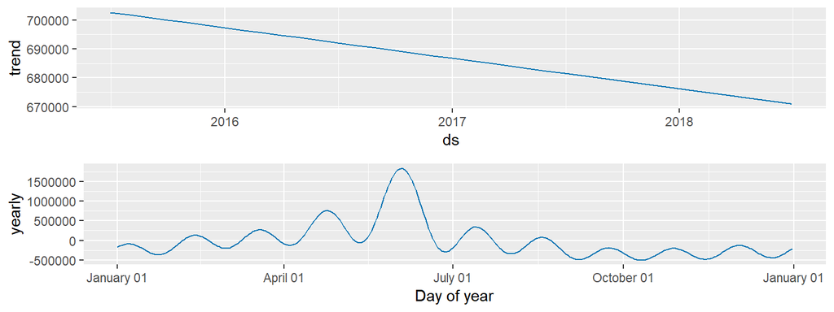

```r
prophet_plot_components(m,forecast)
```

# Adding Custom Seasonalities

# Adding holidays and events

- Adding holidays and events is a major advantage of the package.
- Adding holidays and events is done by creating a new dataframe for them.
- Can also include **lower window** and **upper window** to the holidays.
- Using the lower and upper window parameters, the user can set the length of the holiday.

## Making a dataframe for the holidays

```r
superbowls <- data.frame(
  holiday = 'superbowl',
  ds = as.Date(c('2016-02-07', '2016-01-17',
                 '2016-01-24', '2016-02-07', '2017-04-25', '2017-05-25', '2016-12-08')),
  lower_window = 0,
  upper_window = 20
)
holidays <- superbowls
holidays
```

```
##     holiday         ds lower_window upper_window
## 1 superbowl 2016-02-07            0           20
## 2 superbowl 2016-01-17            0           20
## 3 superbowl 2016-01-24            0           20
## 4 superbowl 2016-02-07            0           20
## 5 superbowl 2017-04-25            0           20
## 6 superbowl 2017-05-25            0           20
## 7 superbowl 2016-12-08            0           20
```

## Making a prediction model

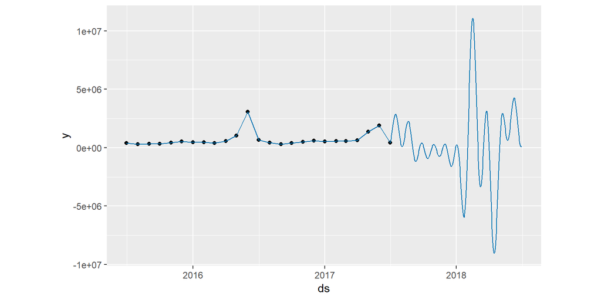

```r
m1 <- prophet(lj1, holidays = holidays)
forecast1 <- predict(m1, future)
plot(m1,forecast1)
```

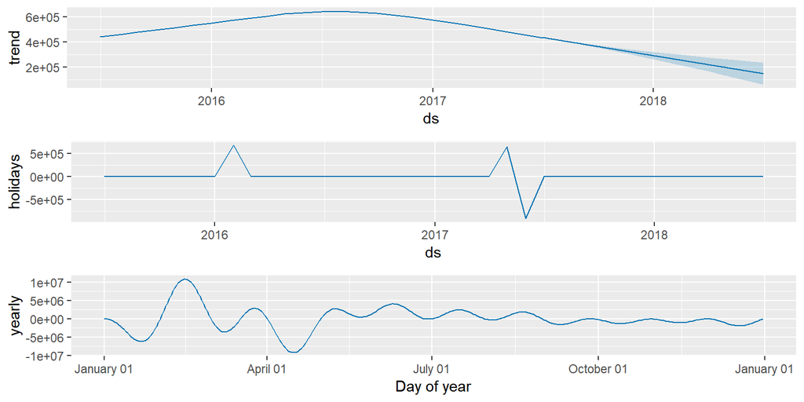

```r
prophet_plot_components(m1, forecast1)
```

# Handling outliers

- It is important to remove outliers from the historical data to make accurate predictions.
- When there is an NA anywhere in the historical data, prophet just ignores these values.
- If there is an NA value for any date in the historical data, prophet gives a prediction for those values.(Cool, isn’t it?)

# Wrapping up

## Where Prophet shines

- Hourly, weekly or daily observations with atleast a few months of history.
- Important holidays that occur at irregular intervals that are known in advance.
- historical trend changes.
- trends that are non-linear growth curves.

## Some limitations of Prophet

- It doesn’t give reliable forecast results when there are large gaps in the historical data. The solution is to only make predictions for only that time period where the historical data is available.
- if the history contains only weekdays, then predictions should only be made for weekdays since the weekly seasonality will not be well estimated for the weekends.
- Same goes for Monthly and yearly data.

## Some More functionalities worth checking out

- Mapping critical trend changepoints.
- Editing uncertainty levels.
- Adding regressors.
- Using prophet for anomaly detection.
- The Documentation for **Prophet** can be found [here](https://cran.r-project.org/web/packages/prophet/prophet.pdf)
- [This](https://facebook.github.io/prophet/) is another useful link for Prophet in R.